# AVK Analyse

```r
date()
```

```
## [1] "Tue Sep 17 18:54:50 2013"
```

```r
getwd()
```

```
## [1] "/home/jcb/Documents/CESU/Travaux/AVK/AVK_Rmd"
```

```r
avk <- read.csv("../data/TABLEAU_AVK7.csv", header = TRUE, sep = ",")
# élimination d'une valeur fausse;
avk[203, 13] <- NA
avk$age <- 2013 - avk$année.de.naissance

names(avk)
```

```
##  [1] "candidat"           "metier"             "session"
##  [4] "année.de.naissance" "sexe"               "Q2"
##  [7] "Q3"                 "Q4"                 "Q5"
## [10] "Q6"                 "Q7"                 "Q8"
## [13] "Q9"                 "Q10"                "Q11"
## [16] "Q12"                "Q13"                "Q14"
## [19] "Q15"                "Q16"                "age"
```

```r
str(avk)
```

```
## 'data.frame':    259 obs. of  21 variables:
##  $ candidat          : int  1 2 3 4 5 6 7 8 9 10 ...
##  $ metier            : Factor w/ 6 levels "DEA","EIADE",..: 6 6 6 6 6 6 6 6 6 6 ...
##  $ session           : int  2013 2013 2013 2013 2013 2013 2013 2013 2013 2013 ...
##  $ année.de.naissance: int  1989 1990 1988 1990 1989 1989 1989 1989 1990 1989 ...
##  $ sexe              : Factor w/ 2 levels "F","H": 1 1 1 1 1 1 1 1 1 1 ...
##  $ Q2                : Factor w/ 3 levels "A","K","V": 3 3 3 1 2 3 3 3 3 2 ...
##  $ Q3                : Factor w/ 3 levels "A","K","V": 3 3 2 2 3 2 3 2 3 3 ...
##  $ Q4                : Factor w/ 3 levels "A","K","V": 2 1 3 3 1 1 1 1 1 1 ...
##  $ Q5                : Factor w/ 3 levels "A","K","V": 1 1 3 1 3 2 2 1 1 1 ...
##  $ Q6                : Factor w/ 3 levels "A","K","V": 1 2 1 2 2 2 1 2 2 3 ...
##  $ Q7                : Factor w/ 3 levels "A","K","V": 2 2 NA 3 1 2 2 1 2 1 ...
##  $ Q8                : Factor w/ 3 levels "A","K","V": 2 2 2 3 3 1 3 1 1 1 ...
##  $ Q9                : Factor w/ 3 levels "A","K","V": 1 1 3 1 1 1 1 3 1 1 ...
##  $ Q10               : Factor w/ 3 levels "A","K","V": 1 2 2 3 3 2 2 3 1 2 ...
##  $ Q11               : Factor w/ 3 levels "A","K","V": 1 1 2 3 3 1 3 3 1 3 ...
##  $ Q12               : Factor w/ 3 levels "A","K","V": 2 2 2 2 2 2 2 3 2 2 ...
##  $ Q13               : Factor w/ 4 levels "A","K","KA","V": 2 2 2 2 NA 4 4 1 1 4 ...
##  $ Q14               : Factor w/ 3 levels "A","K","V": 3 3 1 3 1 2 2 3 1 3 ...
##  $ Q15               : Factor w/ 3 levels "A","K","V": 1 3 3 3 3 1 3 1 1 3 ...
##  $ Q16               : Factor w/ 3 levels "A","K","V": 1 1 2 3 2 1 2 2 3 2 ...
##  $ age               : num  24 23 25 23 24 24 24 24 23 24 ...
```

```r
summary(avk)
```

```
##     candidat       metier      session     année.de.naissance   sexe
##  Min.   :  1.0   DEA  :20   Min.   :2013   Min.   :1957       F   :165
##  1st Qu.: 65.5   EIADE:20   1st Qu.:2013   1st Qu.:1990       H   : 90
##  Median :130.0   EK   :76   Median :2013   Median :1992       NA's:  4
##  Mean   :130.0   EP   :86   Mean   :2013   Mean   :1990
##  3rd Qu.:194.5   ERX  :33   3rd Qu.:2013   3rd Qu.:1992
##  Max.   :259.0   SF   :24   Max.   :2013   Max.   :1994
##                                            NA's   :3
##  Q2         Q3      Q4         Q5      Q6         Q7         Q8
##  A: 19   A   : 35   A:187   A   :115   A:104   A   : 27   A   : 72
##  K: 29   K   : 57   K: 36   K   : 67   K:113   K   :147   K   :112
##  V:211   V   :166   V: 36   V   : 76   V: 42   V   : 80   V   : 71
##          NA's:  1           NA's:  1           NA's:  5   NA's:  4
##
##
##
##     Q9        Q10        Q11      Q12       Q13        Q14        Q15
##  A   :194   A   :102   A   : 94   A: 30   A   :115   A   : 84   A   : 22
##  K   : 13   K   : 31   K   : 49   K:206   K   : 62   K   : 40   K   : 65
##  V   : 50   V   :124   V   :115   V: 23   KA  :  1   V   :134   V   :171
##  NA's:  2   NA's:  2   NA's:  1           V   : 79   NA's:  1   NA's:  1
##                                           NA's:  2
##
##
##  Q16          age
##  A: 76   Min.   :19
##  K: 77   1st Qu.:21
##  V:106   Median :21
##          Mean   :23
##          3rd Qu.:23
##          Max.   :56
##          NA's   :3
```

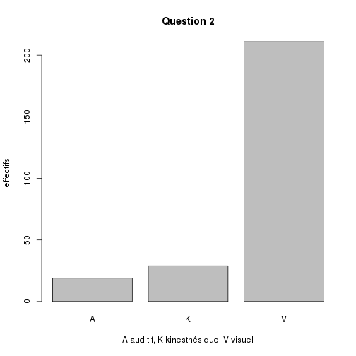

```r
plot(avk$Q2, main = "Question 2", xlab = "A auditif, K kinesthésique, V visuel",
    ylab = "effectifs")
```

## AVK selon le diplome:

```r
t <- table(avk$metier, avk$Q2)
t
```

```
##
##          A  K  V
##   DEA    3  3 14
##   EIADE  0  2 18
##   EK     3  8 65
##   EP     7 10 69
##   ERX    4  3 26
##   SF     2  3 19
```

```r
round(prop.table(t, margin = 1) * 100, 2)
```

```
##
##             A     K     V
##   DEA   15.00 15.00 70.00
##   EIADE  0.00 10.00 90.00
##   EK     3.95 10.53 85.53
##   EP     8.14 11.63 80.23
##   ERX   12.12  9.09 78.79
##   SF     8.33 12.50 79.17
```

```r
for (i in 6:20) {
    print("")
    print(paste("Question", i))
    t <- table(avk$metier, avk[, i])
    print(round(prop.table(t, margin = 1) * 100, 2))
}
```

```
## [1] ""
## [1] "Question 6"
##
##             A     K     V
##   DEA   15.00 15.00 70.00
##   EIADE  0.00 10.00 90.00
##   EK     3.95 10.53 85.53
##   EP     8.14 11.63 80.23
##   ERX   12.12  9.09 78.79
##   SF     8.33 12.50 79.17
## [1] ""
## [1] "Question 7"
##
##             A     K     V
##   DEA    5.00 40.00 55.00
##   EIADE 10.00 20.00 70.00
##   EK    13.16 18.42 68.42
##   EP    17.44 16.28 66.28
##   ERX   12.50 37.50 50.00
##   SF    12.50 20.83 66.67
## [1] ""
## [1] "Question 8"
##
##             A     K     V
##   DEA   60.00 15.00 25.00
##   EIADE 45.00 25.00 30.00
##   EK    77.63 11.84 10.53
##   EP    74.42 16.28  9.30
##   ERX   72.73 12.12 15.15
##   SF    79.17  4.17 16.67
## [1] ""
## [1] "Question 9"
##
##             A     K     V
##   DEA   55.00 40.00  5.00
##   EIADE 25.00 40.00 35.00
##   EK    44.00 28.00 28.00
##   EP    45.35 16.28 38.37
##   ERX   39.39 33.33 27.27
##   SF    58.33 20.83 20.83
```

[output cut: 95 more lines]

```
##   EIADE  5.00 15.00 80.00
##   EK     9.21 30.26 60.53
##   EP     6.98 27.91 65.12
##   ERX   12.12 15.15 72.73
##   SF    17.39 17.39 65.22
## [1] ""
## [1] "Question 20"
##
##             A     K     V
##   DEA   20.00 30.00 50.00
##   EIADE 35.00 25.00 40.00
##   EK    30.26 38.16 31.58
##   EP    24.42 30.23 45.35
##   ERX   33.33 12.12 54.55
##   SF    41.67 29.17 29.17
```

## Faire la somme des lignes

Une ligne correspond à 1 sujet qui répond à 15 questions (Q2 à Q16) où chacune explore l'une des 3 composantes possible de la réponse: A = auditif, K = kinesthésie, V = visuel. En sommant le nombre de A, K, V par ligne on forme un score à 3 composantes pour chaque sujet.

On forme une matrice *a* = *sujet* x *Questions* (la première question, intitulée Q2, correspod à la 6ème colonne du dataframe *avk*):

```r
a <- avk[6]
for (i in 7:20) {
    a <- cbind(a, avk[i])
}
```

On forme *b*, la transposée de *a*:

```r
b <- t(a)
b <- as.data.frame(b)
```

On applique à *b* la méthode *summary* pour calculer la score akv de la ligne et on agglomère les résultats dans la matrice *d*:

```r
d <- summary(as.factor(b[, 1]))
for (i in 2:length(b)) {
    d <- rbind(d, summary(as.factor(b[, i])))
}
```

Enfin on concatène la matrice *d* (3 colonnes x 259 lignes) et la matrice *avk*:

```r
e <- cbind(avk, d)
```

## Score par catégorie socio-professionnelle

```r
tapply(e$A, e$metier, mean)
```

```
##   DEA EIADE    EK    EP   ERX    SF
## 4.600 4.700 4.908 4.919 5.182 5.417
```

```r
tapply(e$K, e$metier, mean)
```

```
##   DEA EIADE    EK    EP   ERX    SF
## 4.950 4.700 4.382 4.140 4.394 4.167
```

```r
tapply(e$V, e$metier, mean)
```

```
##   DEA EIADE    EK    EP   ERX    SF
## 5.450 5.900 5.592 5.907 5.455 5.250
```

```r
print("Les boxplot qui suivent expriment le nombre de fois ou des réponses correspondant à un trait spécifique (auditif, visuel, kinesthésique) ont été choisies, selon la catégorie socio-professionnelle. Pour chaque question, le choix verie entre 0 et 15.")
```

```
## [1] "Les boxplot qui suivent expriment le nombre de fois ou des réponses correspondant à un trait spécifique (auditif, visuel, kinesthésique) ont été choisies, selon la catégorie socio-professionnelle. Pour chaque question, le choix verie entre 0 et 15."
```

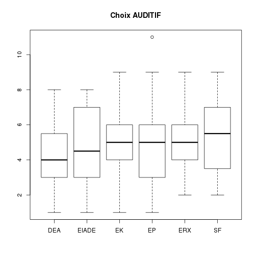

```r
boxplot(e$A ~ e$metier, main = "Choix AUDITIF")
```

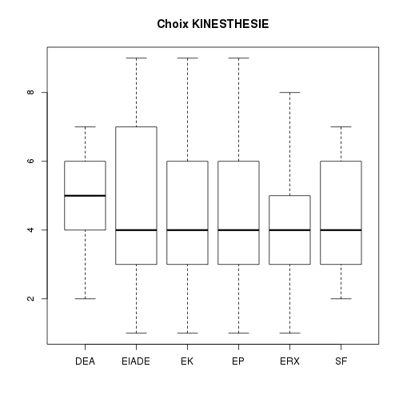

```r
boxplot(e$K ~ e$metier, main = "Choix KINESTHESIE")
```

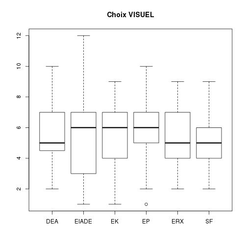

```r
boxplot(e$V ~ e$metier, main = "Choix VISUEL")
```

```r
print("Pas de différence en moyenne entre les hommes et la femmes sur le choix d'une composante:")
```

```
## [1] "Pas de différence en moyenne entre les hommes et la femmes sur le choix d'une composante:"
```

```r
tapply(e$A, e$sexe, mean)
```

```
##     F     H
## 5.006 4.867
```

```r
tapply(e$K, e$sexe, mean)
```

```
##     F     H
## 4.267 4.433
```

```r
tapply(e$V, e$sexe, mean)
```

```
##     F     H
## 5.673 5.700
```

## Dominante

Hypothèse: dans certains groupes professionnel, une des 3 traits (visuel, kinesthésique, auditif) est dominant. On trouve dans les colonnes K, V, A la somme des réponses aux questions. Pour un individu, on choisit l'item correspondant à la somme maximale. Par exemple pour le sujet 1 on a: A=7 K=5 V=3. Son trait dominant est auditif.

On met dans la colonne e$trait, le trait dominant:

```r
source("../fct.R")
#' par défaut la fonction trait dominant élimine les ex-aequo et met NA dans la colonne trait (?)
e$trait <- as.factor(trait_dominant(e))
summary(e$trait)
```

```
##   A   K  NA   V
##  70  47  36 106
```

#### Relation *trait* et *age*:

```r
tapply(e$age, e$trait, mean, na.rm = T)
```

```
##     A     K    NA     V
## 22.41 24.02 23.74 22.63
```

```r
tapply(e$age, e$trait, sd, na.rm = T)
```

```
##     A     K    NA     V
## 3.470 6.288 5.744 3.898
```

Pas de diddérence entre les groupes

#### Relation *trait* rt *métier*

```r
t <- table(e$metier, e$trait)
t
```

```
##
##          A  K NA  V
##   DEA    4  6  1  9
##   EIADE  3  3  6  8
##   EK    22 14 10 30
##   EP    23 14 10 39
##   ERX    9  5  6 13
##   SF     9  5  3  7
```

```r
pt <- round(prop.table(t) * 100, 2)
pt
```

```
##
##             A     K    NA     V
##   DEA    1.54  2.32  0.39  3.47
##   EIADE  1.16  1.16  2.32  3.09
##   EK     8.49  5.41  3.86 11.58
##   EP     8.88  5.41  3.86 15.06
##   ERX    3.47  1.93  2.32  5.02
##   SF     3.47  1.93  1.16  2.70
```

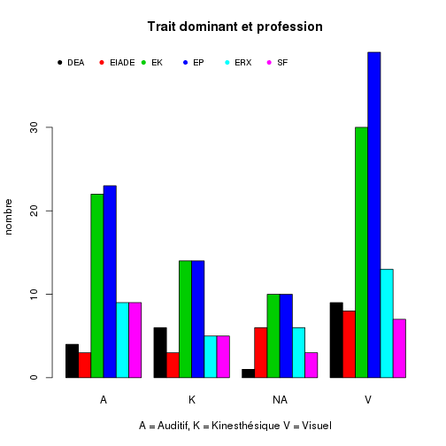

```r
barplot(t, beside = T, col = 1:6, main = "Trait dominant et profession", ylab = "nombre",
    xlab = "A = Auditif, K = Kinesthésique V = Visuel")
legend("topleft", 5, pch = 19, bty = "n", horiz = T, legend = c("DEA", "EIADE",
    "EK", "EP", "ERX", "SF"), cex = 0.8, col = 1:6)
```

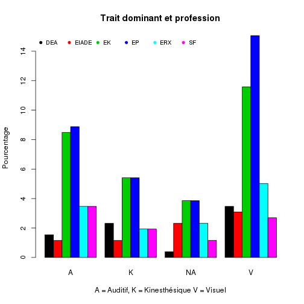

```r
barplot(pt, beside = T, col = 1:6, main = "Trait dominant et profession", ylab = "Pourcentage",
    xlab = "A = Auditif, K = Kinesthésique V = Visuel")
legend("topleft", 5, pch = 19, bty = "n", horiz = T, legend = c("DEA", "EIADE",
    "EK", "EP", "ERX", "SF"), cex = 0.8, col = 1:6)
```

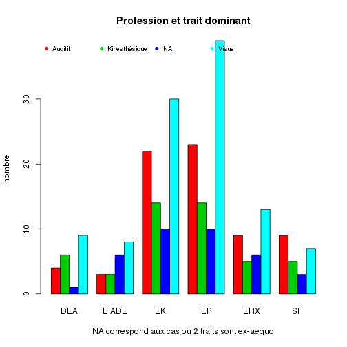

```r
barplot(t(t), beside = T, col = 2:5, main = "Profession et trait dominant",
    ylab = "nombre", xlab = "NA correspond aux cas où 2 traits sont ex-aequo")
legend("topleft", 5, pch = 19, bty = "n", horiz = T, legend = c("Auditif", "Kinesthésique",
    "NA", "Visuel"), cex = 0.8, col = 2:5)
```

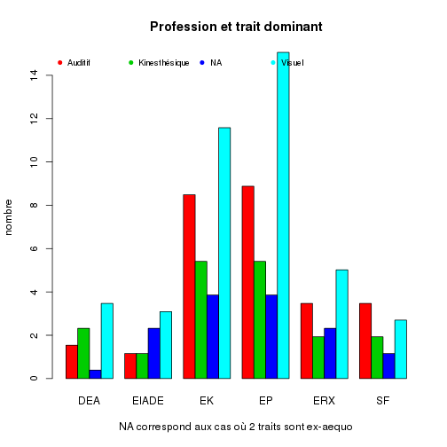

```r
barplot(t(pt), beside = T, col = 2:5, main = "Profession et trait dominant",
    ylab = "nombre", xlab = "NA correspond aux cas où 2 traits sont ex-aequo")
legend("topleft", 5, pch = 19, bty = "n", horiz = T, legend = c("Auditif", "Kinesthésique",
    "NA", "Visuel"), cex = 0.8, col = 2:5)
```

Existe t-il un groupe où le trait K est dominant ?  
Pour chaque ligne, on regarde si le trait dominant est K ou non (NK): ** A revoir, le calcul est faux **

```r
for (i in 1:length(e)) {
    e$traitK[i] <- ifelse(e$K[i] == max(e[i, c("A", "K", "V")]), "K", "NK")
}
summary(as.factor(e$trait))
```

```
##   A   K  NA   V
##  70  47  36 106
```

On refait le meme calcul pour les autres caractéristiques:

```r
for (i in 1:length(e)) {
    e$traitA[i] <- ifelse(e$A[i] == max(e[i, c("A", "K", "V")]), "A", "NA")
}
summary(as.factor(e$traitA))
```

```
##   A  NA
## 244  15
```

```r
for (i in 1:length(e)) {
    e$traitV[i] <- ifelse(e$V[i] == max(e[i, c("A", "K", "V")]), "V", "NV")
}
summary(as.factor(e$traitV))
```

```
##  NV   V
## 247  12
```

#### Conclusion

```r
e$age <- 2013 - e$année.de.naissance
summary(e$age)
```

```
##    Min. 1st Qu.  Median    Mean 3rd Qu.    Max.    NA's
##      19      21      21      23      23      56       3
```

sex ratio

```r
summary(e$sexe)
```

```
##    F    H NA's
##  165   90    4
```

# Analyse 2

```r
source("../fct.R")
e$trait <- trait_dominant(e)
summary(as.factor(e$trait))
```

```
##   A   K  NA   V
##  70  47  36 106
```

```r
apply(e$age, e$trait, mean, na.rm = T)
```

```
## Error: dim(X) must have a positive length
```

```r
table(e$metier, e$trait)
```

```
##
##          A  K NA  V
##   DEA    4  6  1  9
##   EIADE  3  3  6  8
##   EK    22 14 10 30
##   EP    23 14 10 39
##   ERX    9  5  6 13
##   SF     9  5  3  7
```

```r
t <- table(e$metier, e$trait)
t
```

```
##
##          A  K NA  V
##   DEA    4  6  1  9
##   EIADE  3  3  6  8
##   EK    22 14 10 30
##   EP    23 14 10 39
##   ERX    9  5  6 13
##   SF     9  5  3  7
```

```r
round(prop.table(t, margin = 1) * 100, 2)
```

```
##
##             A     K    NA     V
##   DEA   20.00 30.00  5.00 45.00
##   EIADE 15.00 15.00 30.00 40.00
##   EK    28.95 18.42 13.16 39.47
##   EP    26.74 16.28 11.63 45.35
##   ERX   27.27 15.15 18.18 39.39
##   SF    37.50 20.83 12.50 29.17
```

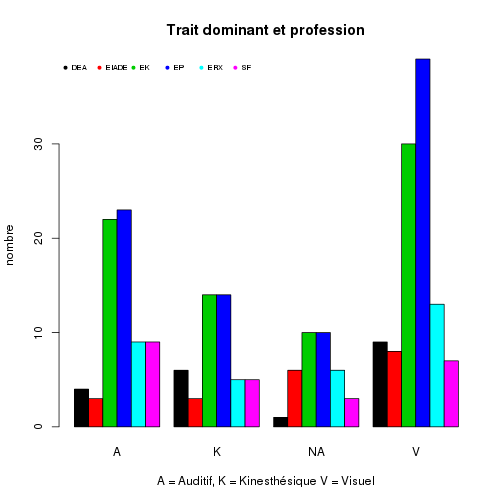

```r
barplot(t, beside = T, col = 1:6, main = "Trait dominant et profession", ylab = "nombre",
    xlab = "A = Auditif, K = Kinesthésique V = Visuel")
legend("topleft", 5, pch = 19, bty = "n", horiz = T, legend = c("DEA", "EIADE",
    "EK", "EP", "ERX", "SF"), cex = 0.6, col = 1:6)
```

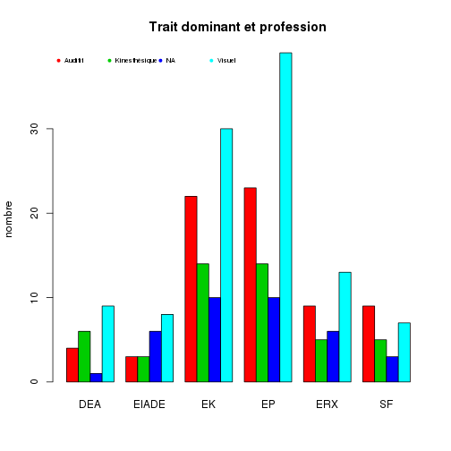

```r
barplot(t(t), beside = T, col = 2:5, main = "Trait dominant et profession",
    ylab = "nombre", xlab = "")
legend("topleft", 5, pch = 19, bty = "n", horiz = T, legend = c("Auditif", "Kinesthésique",
    "NA", "Visuel"), cex = 0.6, col = 2:5)
```

```r
tapply(e$age, e$trait, var, na.rm = T)
```

```
##     A     K    NA     V
## 12.04 39.54 32.99 15.20
```

```r
tapply(e$age, e$trait, sd, na.rm = T)
```

```
##     A     K    NA     V
## 3.470 6.288 5.744 3.898
```

```r
a <- summary(t(e[, c(6:20)]))
a
```

[output not shown]

[output cut: 83 more lines]

[output not shown]

```r
a <- trait_dominant(e)
s <- summary(as.factor(a))
t <- round(prop.table(as.table(s)) * 100, 2)
r <- rbind(s, t)
row.names(r) <- c("n", "%")
r
```

```
##       A     K   NA      V
## n 70.00 47.00 36.0 106.00
## % 27.03 18.15 13.9  40.93
```

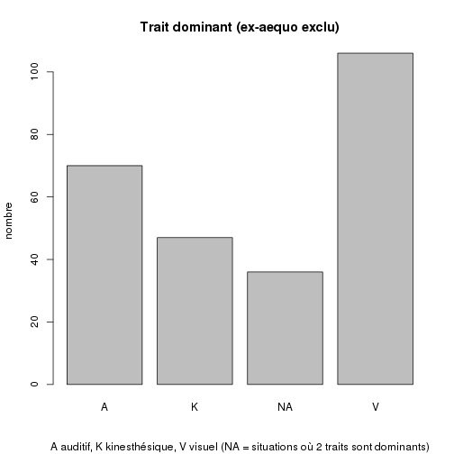

```r
barplot(r[1, ], main = "Trait dominant (ex-aequo exclu)", ylab = "nombre", sub = "A auditif, K kinesthésique, V visuel (NA = situations où 2 traits sont dominants)")
```

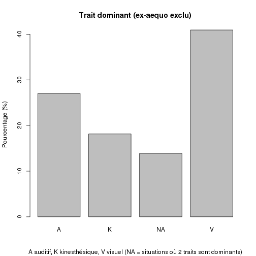

```r
barplot(r[2, ], main = "Trait dominant (ex-aequo exclu)", ylab = "Pourcentage (%)",
    sub = "A auditif, K kinesthésique, V visuel (NA = situations où 2 traits sont dominants)")
```

```r
a <- trait_dominant(e, ties = F)
s <- summary(as.factor(a))
t <- round(prop.table(as.table(s)) * 100, 2)
r <- rbind(s, t)
row.names(r) <- c("n", "%")
r
```

```
##       A     K NA      V
## n 99.00 47.00  0 113.00
## % 38.22 18.15  0  43.63
```

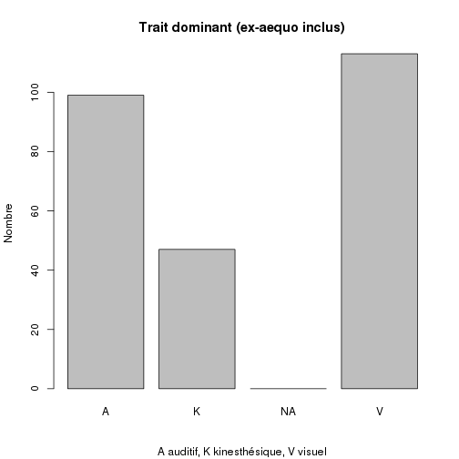

```r
barplot(r[1, ], main = "Trait dominant (ex-aequo inclus)", ylab = "Nombre",
    sub = "A auditif, K kinesthésique, V visuel")
```

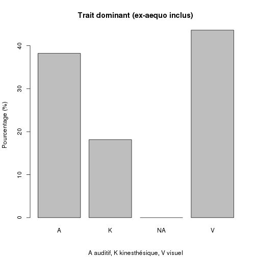

[output not shown]

```r
barplot(r[2, ], main = "Trait dominant (ex-aequo inclus)", ylab = "Pourcentage (%)",
    sub = "A auditif, K kinesthésique, V visuel")
```